# Porządkowanie Liniowe

Wiktoria Paluch

## Cel pracy

Praca skupia się na analizie zbioru danych - piwo.csv, w którym zebrano informacje odnośnie 20 popularnych marek piw. Celem projektu jest wyłonienie najlepszych marek pod względem “jakości”, a więc najbardziej uniwersalnych i opłacalnych zarówno pod względem jakości jak i ceny. Praca może pomóc osobom, które mają problemy ze zdecydowaniem jaką markę piwa wybrać w gronie znajomych, aby możliwość, że każdemu ona odpowiada była największa.

Praca zakłada stworzenie(przynajmniej trzema sposobami metod porządkowania liniowego) rankingów i analizę. Rankingi następnie porównano i na podstawie jednego z nich podzielono obserwacje na grupy pod względem “jakości”. Wszystkie badania zostały przeprowadzone w programie Rstudio.

W analizie skorzystano z czterech metod porządkowania liniowego : metody standaryzowanych sum, metody sumy rang, metody Hellwiga, metody Topsis do stworzenia czterech rankingów na ich podstawie.

## Analiza zmiennych

Zbiór danych zawiera następujące zmienne:

- zawartość alkoholu - procentowa zawartość alkoholu w butelce piwa [%],
- cena - cena jednostkowa za butelkę piwa [zł],
- dostępność - dostępność w wybranych krakowskich sklepach spożywczych[pkt],
- znajomość - rozpoznawalność marki wśród ankietowanych[pkt],
- preferencje - preferencje ankietowanych do danej marki piwa[pkt].

Wykres pudełkowy zmiennych

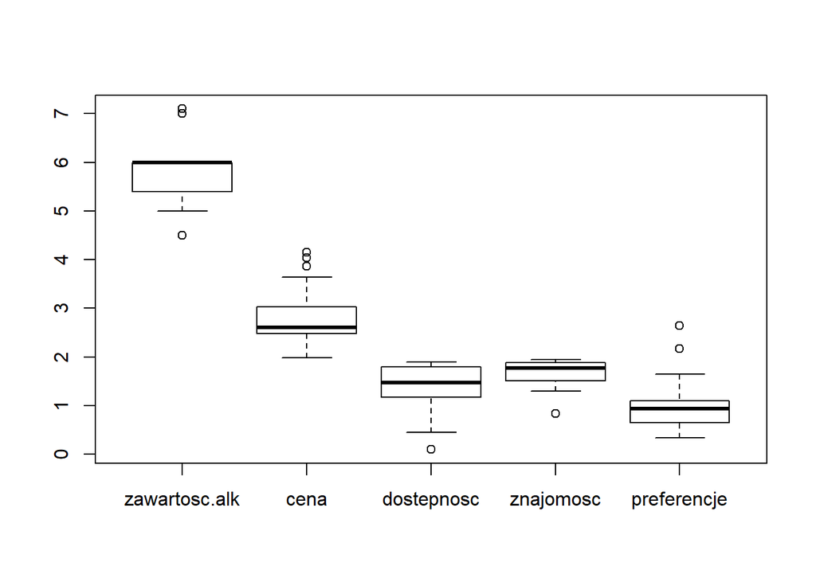

```r
boxplot(piwo)
```

Statystyki opisowe zmiennych:

```r
summary(piwo) #describe(piwo)
```

```
##  zawartosc.alk        cena         dostepnosc      znajomosc
##  Min.   :4.500   Min.   :1.990   Min.   :0.100   Min.   :0.840
##  1st Qu.:5.500   1st Qu.:2.485   1st Qu.:1.188   1st Qu.:1.552
##  Median :6.000   Median :2.610   Median :1.475   Median :1.770
##  Mean   :5.795   Mean   :2.825   Mean   :1.397   Mean   :1.675
##  3rd Qu.:6.000   3rd Qu.:2.967   3rd Qu.:1.800   3rd Qu.:1.877
##  Max.   :7.100   Max.   :4.150   Max.   :1.900   Max.   :1.950
##   preferencje
##  Min.   :0.3400
##  1st Qu.:0.7075
##  Median :0.9350
##  Mean   :1.0170
##  3rd Qu.:1.0800
##  Max.   :2.6500
```

**Statystyki opisowe:**

- Minimalna zawartość alkoholu badanych piw to 4.5%, natomiast największa to 7.1%, Mediana wynosi 6%, współczynnik asymetrii bliski 0, zatem rozkład jest symetryczny
- minimalna cena to 1.99 zł a maksymalna badanych piw to 4.15 zł, mediana równa 2.61zł, asymetria prawostronna, odchylenie standardowe na poziomie 0.64zł
- Najmniej dostępne piwo uzyskało wskaźnik równy 0.1pkt a największa wrtość to 1.9pkt, asymetria lewostronna, wartość ochyla się przeciętnie o 0.47pkt
- Znajomość na poziomie pomiędzy 0.84 - 1.95, zatem brane są pod uwagę dość rozpoznawalne marki piwa, lewostronna asymetria, dane skumulowane wokół średniej równej 1.68 pkt
- Duża dysproporcja pomiędzy preferencjami piwa, wartość minimalna wskaźnika to 0.34 a maksymalna to 2.65, asymetria prawostronna

**Występują obserwacje odstające jednak patrząc na charakter danych i wartości obserwacji można przyjąć, że nie będą miały negatywnego wpływu na dalszy przebieg badań, a wręcz są konieczne w uwzględnieniu.**

**Stymulanty:** dostępność, znajomość, preferencje  
**Destymulanta:** cena  
**Nominanta:** zawartość alkoholu (zał: idealne piwo ma 5.5%)

Wszystkie zmienne zostały zamienione na stymulanty, w celu dalszych badań, a następnie zestandaryzowane(znormalizowane dla metody Topsis inną metodą), aby można było porównywać ich wartości.

## Tworzenie Rankingów

**Metoda standaryzowanych sum**

Algorytm

- Zamiana zmiennych na stymulanty.
- Standaryzacja (zapewnia porównywalność cech).
- Suma oszacowań uzyskanych w ramach obiektów.
- Standaryzacja wartości

```r
standaryzacja_sum[,6:7]
```

```
##                st_sumy ranking
## Zywiec       1.0000000       1
## Desperados   0.4107104      13
## Kasztelan    0.8994888       2
## Wojak        0.2544741      16
## Tyskie       0.8806959       3
## Heineken     0.5051710      10
## Warka        0.6522651       6
## Łomża        0.4340449      11
## Lech         0.6840168       4
## Perła        0.6715033       5
## Specjal      0.0000000      20
## Żubr         0.5740640       8
## Redds        0.2702006      15
## Carlsberg    0.5552673       9
## Somersby     0.2046268      17
## Tatra_Pils   0.4302300      12
## Harnas       0.6365060       7
## Tatra_mocne  0.1650320      18
## Okocim_mocne 0.3334416      14
## Debowe_mocne 0.1379155      19
```

**Metoda sumy rang**

Algorytm

- wyznaczenie rang dla każdej z cech.
- wyznaczenie sumy w raamach obiektów.

```r
Suma_rang
```

```
##              zawartosc.alk cena dostepnosc znajomosc preferencje suma ranking
## Zywiec                 1.5   15        1.5       1.0           1 20.0       2
## Desperados            10.5   20        3.5      10.5          11 55.5      11
## Kasztelan              3.5    5        5.5       7.5           2 23.5       3
## Wojak                 10.5    3       19.0      18.0          18 68.5      14
## Tyskie                 1.5    7        1.5       2.0           4 16.0       1
## Heineken              10.5   17        8.0       4.5           5 45.0       8
## Warka                  3.5    9       15.0       3.0           6 36.5       5
## Łomża                 10.5   10       17.5      13.5          14 65.5      13
## Lech                   5.0   13        5.5       4.5           7 35.0       4
## Perła                 10.5    8        9.0       9.0           3 39.5       6
## Specjal               10.5    4       20.0      20.0          17 71.5      17
## Żubr                  10.5    6       10.0       7.5          12 46.0       9
## Redds                 16.5   18       12.0      12.0          10 68.5      15
## Carlsberg             10.5   16        3.5       6.0          13 49.0      10
## Somersby              16.5   19       13.5      15.0           9 73.0      18
## Tatra_Pils            10.5    2       11.0      19.0          16 58.5      12
## Harnas                10.5    1        7.0      13.5           8 40.0       7
## Tatra_mocne           18.5   11       17.5      16.5          19 82.5      19
## Okocim_mocne          20.0   12       13.5      10.5          15 71.0      16
## Debowe_mocne          18.5   14       16.0      16.5          20 85.0      20
```

**Metoda Hellwiga**

Algorytm

- Standaryzacja zmiennych
- Stworzenie wzorca (𝑑+), tj. „Najlepszego” obiektu.
- Obliczenie odległości obiektów od wzorca.
- Obliczenie odległości “możliwie dalekiej”.
- Znalezienie wartości WSK dla obiektów.

```r
hellwig[,6:8]
```

```
##                  suma        WSK ranking
## Zywiec       1.420880 0.79928227       2
## Desperados   4.798296 0.32217854      13
## Kasztelan    1.286646 0.81824458       1
## Wojak        5.501458 0.22284788      17
## Tyskie       2.143642 0.69718282       3
## Heineken     3.996137 0.43549396      10
## Warka        3.236978 0.54273494       6
## Łomża        4.122903 0.41758653      11
## Lech         3.148486 0.55523561       5
## Perła        2.635082 0.62776050       4
## Specjal      6.878709 0.02829338      20
## Żubr         3.647521 0.48474041       8
## Redds        5.045534 0.28725306      15
## Carlsberg    3.926261 0.44536485       9
## Somersby     5.310389 0.24983885      16
## Tatra_Pils   4.622228 0.34705047      12
## Harnas       3.368143 0.52420626       7
## Tatra_mocne  5.741170 0.18898545      18
## Okocim_mocne 4.981912 0.29624051      14
## Debowe_mocne 5.809727 0.17930085      19
```

**Metoda Topsis**

Algorytm

- Obliczyć macierz znormalizowaną
- Wyznaczyć wzorzec i antywzorzec.
- Obliczyć odległości od wzorca i antywzorca.
- Wyznaczyć współczynnik rankingowy określający podobieństwo obiektów do rozwiązania idealnego.

```r
piwo_norm[,6:9]
```

```
##                      wz        awz       wsk ranking
## Zywiec       0.05212713 0.19548191 0.7894781       2
## Desperados   0.16056362 0.11891413 0.4254869      15
## Kasztelan    0.04004207 0.18350678 0.8208800       1
## Wojak        0.15810265 0.12459520 0.4407363      14
## Tyskie       0.07382342 0.16825062 0.6950379       3
## Heineken     0.13004364 0.11951691 0.4789095      13
## Warka        0.10538650 0.13470231 0.5610520       7
## Łomża        0.12255615 0.11969249 0.4940894      12
## Lech         0.10426465 0.14514578 0.5819555       6
## Perła        0.07089557 0.15507344 0.6862598       4
## Specjal      0.17744810 0.10392882 0.3693580      19
## Żubr         0.11156533 0.14072463 0.5577893       8
## Redds        0.14946528 0.09778073 0.3954795      17
## Carlsberg    0.12561700 0.13303561 0.5143409      10
## Somersby     0.15772953 0.08990832 0.3630637      20
## Tatra_Pils   0.12928445 0.14915758 0.5356863       9
## Harnas       0.09691202 0.16485491 0.6297774       5
## Tatra_mocne  0.14988092 0.11020361 0.4237223      16
## Okocim_mocne 0.12494919 0.12225364 0.4945479      11
## Debowe_mocne 0.15400246 0.10004521 0.3938049      18
```

### Zestawienie rankingów na podstawie czterech metod wygląda następująco:

```r
zestawienie
```

```
##       standaryzacja  suma_rang      Hellwig        Topsis
##  [1,] "Zywiec"       "Tyskie"       "Kasztelan"    "Kasztelan"
##  [2,] "Kasztelan"    "Zywiec"       "Zywiec"       "Zywiec"
##  [3,] "Tyskie"       "Kasztelan"    "Tyskie"       "Tyskie"
##  [4,] "Lech"         "Lech"         "Perła"        "Perła"
##  [5,] "Perła"        "Warka"        "Lech"         "Harnas"
##  [6,] "Warka"        "Perła"        "Warka"        "Lech"
##  [7,] "Harnas"       "Harnas"       "Harnas"       "Warka"
##  [8,] "Żubr"         "Heineken"     "Żubr"         "Żubr"
##  [9,] "Carlsberg"    "Żubr"         "Carlsberg"    "Tatra_Pils"
## [10,] "Heineken"     "Carlsberg"    "Heineken"     "Carlsberg"
## [11,] "Łomża"        "Desperados"   "Łomża"        "Okocim_mocne"
## [12,] "Tatra_Pils"   "Tatra_Pils"   "Tatra_Pils"   "Łomża"
## [13,] "Desperados"   "Łomża"        "Desperados"   "Heineken"
## [14,] "Okocim_mocne" "Wojak"        "Okocim_mocne" "Wojak"
## [15,] "Redds"        "Redds"        "Redds"        "Desperados"
## [16,] "Wojak"        "Okocim_mocne" "Somersby"     "Tatra_mocne"
## [17,] "Somersby"     "Specjal"      "Wojak"        "Redds"
## [18,] "Tatra_mocne"  "Somersby"     "Tatra_mocne"  "Debowe_mocne"
## [19,] "Debowe_mocne" "Tatra_mocne"  "Debowe_mocne" "Specjal"
## [20,] "Specjal"      "Debowe_mocne" "Specjal"      "Somersby"
```

Od razu widać, że występują podobieństwa pomiędzy rankingami, jednak aby przekonać się o faktycznym podobieństwie uporządkowań należy posłużyć się współczynnikiem korelacji Kendalla.

**Porównanie rankingów współczynnikiem korelacji Kendalla**

**tau Kendalla** - Współczynnik ten przyjmuje wartości z przedziału <-1, 1>. Wartość 1 oznacza pełną zgodność, wartość 0 brak zgodności uporządkowań, natomiast wartość -1 całkowitą ich przeciwstawność. Współczynnik Kendalla wskazuje, więc nie tylko siłę, lecz również kierunek zależności. Jest doskonałym narzędziem do opisu podobieństwa uporządkowań zbioru danych.

Tabela korelacji (Kendall) pomiędzy rankingami

```r
tabela_kor
```

```
##      [,1]      [,2]      [,3]      [,4]
## [1,]    1 0.9684211 0.8526316 0.8210526
## [2,]   NA 1.0000000 0.8210526 0.8315789
## [3,]   NA        NA 1.0000000 0.7368421
## [4,]   NA        NA        NA 1.0000000
```

Widać, że rozmieszczenie pozycji w rankingach jest do siebie podobne, wysoki współczynnik korelacji Kendalla świadczy o wysokim podobieństwie uporządkowania zbiorów, zatem za pomocą wszystkich czterech metod uzyskano podobne wyniki.

## Podział na grupy

Podział na grupy względem jakości najlepiej przeprowadzić na rankingu najlepiej dopasowanym do pozostałych. Aby wybrać ranking najlepiej dopasowany do pozostałych należy porównać średnie dopasowanie rankingów (średnia z dopasowań)

```r
miary_dopasowania
```

```
## [1] 0.8807018 0.8736842 0.8035088 0.7964912
```

Największe dopasowanie ma ranking nr1, zatem ten stworzony metodą standaryzowanych sum. Na jego podstawie najlepiej będzie dokonać podziału obserwacji na grupy pod względem “jakości”, gdyż jest on najbardziej zbliżony do pozostałych rankingów, zatem po pewnych przybliżeniach można go będzie przyjąć dla wszystkich rankingów.

#### Grupa 1 “Najlepsza”

```r
row.names(standaryzacja_sum[gr1,])
```

```
## [1] "Zywiec"    "Kasztelan" "Tyskie"
```

#### Grupa 2

```r
row.names(standaryzacja_sum[gr2,])
```

```
## [1] "Heineken"  "Warka"     "Lech"      "Perła"     "Żubr"      "Carlsberg"
## [7] "Harnas"
```

#### Grupa 3

```r
row.names(standaryzacja_sum[gr3,])
```

```
## [1] "Desperados"   "Wojak"        "Łomża"        "Redds"        "Tatra_Pils"
## [6] "Okocim_mocne"
```

#### Grupa 4

```r
row.names(standaryzacja_sum[gr4,])
```

```
## [1] "Specjal"      "Somersby"     "Tatra_mocne"  "Debowe_mocne"
```

## Podsumowanie

Najlepsze okazały się być trzy marki piwa “Żywiec”, “Kasztelan” i “Tyskie”. Są one najbardziej opłacalne pod względem badanych cech. Do drugiej grupy należą : “Heineken”, “Warka”, “Lech”, “Perła”, “Żubr”, “Carlsberg”, “Harnaś”, zatem są gorsze od pierwszej grupy, jednak wciąż powyżej przeciętnej. Grupa 3 to piwa już gorszej jakości, poniżej przeciętnego wyniku testu i należą do niej: “Desperados”, “Wojak”, “Łomża”, “Redds”, “Tatra Pils”, “Okocim mocne”. Grupa 4 to najsłabsze piwa według badanych cech. Są to piwa specyficzne, raczej trafiające w małe grono odbiorców, ze względu na swoją specyfikacje.